# Lab 14: Statistics

Analysis of Diff-in-Diff Data

Author

Bogdan G. Popescu

# 1 Introduction

In this document, we want to calculate $\beta_3$ from:

$$Y_{it} = \beta_0 + \beta_1 \text{Group}_i + \beta_2 \text{Time}_t +\beta_3 (\text{Group}_i \times \text{Time}_t) + \epsilon_{it}$$

where:  
Group = 1 if this is the treatment group  
Time = 1 if this is the period after intervention  
$\beta_0$ - mean of the control group in the pre-treatment period  
$\beta_1$ - the increase in outcome across groups  
$\beta_2$ - the increase in outcome within groups.  
$\beta_3$ - the differences in differences

In our case, this is equivalent to:

$$\text{Malaria Risk}_{it} = \beta_0 + \beta_1 \text{City B}_i + \beta_2 \text{Post-2017}_t +\beta_3 (\text{City B}_i \times \text{Post-2017}_t) + \epsilon_{it}$$

```r
library("broom")
library("dplyr")
library("ggplot2")
library("ggrepel")
library("modelsummary")
library("ggdag")
library("purrr")
library("stringr")
library("ggpubr")

# For Maps
library("sf")
library("stars")
library("rnaturalearth")
library("rnaturalearthdata")
library("ggspatial")
library("gganimate")
library("lemon")


# Removing previous files and setting the
# directory
rm(list = ls())
setwd("/Users/bgpopescu/Dropbox/john_cabot/teaching/stats/lab14/")
```

In a first instance, we want to draw a causal model which explains the effect of the insecticide-treated bed nets on participant risk of malaria, given the time and group. See the models below (together with the code to produce them).

```r
malaria_dag <- dagify(malaria_risk ~ net + year + city,
                     net ~ year + city,
                     exposure = "net",
                     outcome = "malaria_risk",
                     labels = c(malaria_risk = "Malaria Risk",
                                net = "Mosquito Net",
                                year = "Year",
                                city = "City",
                                pre_malaria_risk = "Pre Malaria Risk"),
                     coords = list(x = c(malaria_risk = 3, net = 1, year = 2, city = 2),
                                   y = c(malaria_risk = 2, net = 2, year = 3, city = 1)))

bigger_dag <-data.frame(tidy_dagitty(malaria_dag))
bigger_dag$type<-NA
#bigger_dag$type<-"Confounder"
bigger_dag$type<-""
bigger_dag$type[bigger_dag$name=="malaria_risk"]<-"Outcome"
bigger_dag$type[bigger_dag$name=="net"]<-"Intervention"
min_lon_x<-min(bigger_dag$x)
max_lon_x<-max(bigger_dag$x)
min_lat_y<-min(bigger_dag$y)
max_lat_y<-max(bigger_dag$y)
```

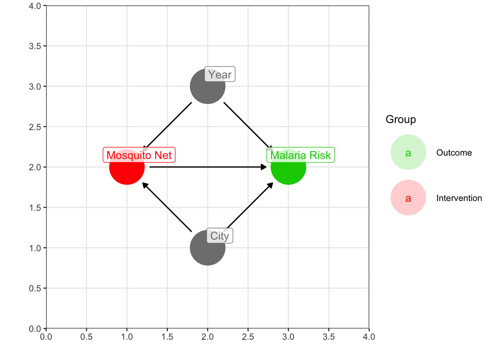

```r
col = c("Outcome"="green3",
        "Intervention"="red",
        "Confounder"="grey60")

order_col<-c("Outcome", "Intervention", "Confounder")


example_dag<-ggplot(data = bigger_dag, aes(x = x, y = y, xend = xend, yend = yend, color=type)) +
  geom_dag_point() +
  geom_dag_edges() +
  coord_sf(xlim = c(min_lon_x-1, max_lon_x+1), ylim = c(min_lat_y-1, max_lat_y+1), expand = FALSE)+
    scale_colour_manual(values = col,
                      name = "Group",
                      breaks = order_col)+
        geom_label_repel(data = subset(bigger_dag, !duplicated(bigger_dag$label)),
                   aes(label = label), fill = alpha(c("white"),0.8))+

    theme_bw()+
  labs(x = "", y="")
ggsave(example_dag, file = "./graphs/example_dag1.jpg",
       height = 20, width = 25,
       units = "cm", dpi = 200)

example_dag
```

# 2 Loading the Data

Create a folder called lab12. Within it, create another folder and call it data. Go to the following links and download the following:

- [Shapefiles](https://www.dropbox.com/sh/ozemmsft1bizcqe/AADRxAST18DKhHtj5orqmm6Qa?dl=0)
- [Elevation Data](https://www.dropbox.com/s/ndxejape9pbmo9p/elev.tif?dl=0)
- [Diff-in-Diff Data](https://www.dropbox.com/s/xrittumjd0c9g73/did_data_geo_malawi.csv?dl=0)

Place all the data in the data folder.

## 2.1 Loading the Shape Files

`st_read` reads the shapefiles from your hardrive. `read_stars` reads a tif file that shows the elevation for your area of interest. `ne_countries` loads a shapefile with all the countries around the world.

```r
#Country shapefile
mwi <- st_read("./data/malawi-latest-free/gadm41_MWI_0.shp")
#Region 1 shapefile
mwi1 <- st_read("./data/malawi-latest-free/gadm41_MWI_1.shp")
#Region 3 shapefile
mwi3 <- st_read("./data/malawi-latest-free/gadm41_MWI_3.shp")
#Selected communes shapefile
select_comm <- st_read("./data/malawi-latest-free/selected_communes3.shp")
#Raster with elevation
elev <- read_stars("./data/elev.tif")
#World Shapefile
world <- ne_countries(scale = "medium", returnclass = "sf")
#Switched off spherical geometry (s2)
sf::sf_use_s2(FALSE)
```

## 2.2 Simplifying the shapefiles for better rendering

`st_simplify` simplifies the polygons for quicker rendering.

```r
#Simplifying polygons for quicker rendering
#Note: you have to play around with dTolerance to figure out the appropriate value
#Too little - your computer will need more time to render the file
#Too much - the country polygons will be too simple
mwi<-st_simplify(mwi,  dTolerance = 0.005)
mwi1<-st_simplify(mwi1,  dTolerance = 0.005)
mwi3<-st_simplify(mwi3,  dTolerance = 0.005)
select_comm<-st_simplify(select_comm,  dTolerance = 0.0005)
world<-st_simplify(world,  dTolerance = 0.005)
```

## 2.3 Calculating the appropriate zoom level for Malawi

We now calculate the zoom level for the entire country of Malawi.

```r
#Calculating the appropriate zoom level
mwi_extent <- st_bbox(mwi)

min_lon_x<-mwi_extent["xmin"]
max_lon_x<-mwi_extent["xmax"]

min_lat_y<-mwi_extent["ymin"]
max_lat_y<-mwi_extent["ymax"]
```

We now create a new polygon to emphasize where Malawi is on the World Map.

```r
#Creating a dataframe to emphasize Malawi and adding some error
error = 5

sp_df = data.frame("lon" = c(min_lon_x - error, max_lon_x + error,
                             min_lon_x - error, max_lon_x + error),
                   "lat" = c(min_lat_y - error, min_lat_y - error,
                             max_lat_y + error, max_lat_y + error))
```

We now make a spatial polygon out of it so that we can highlight where Malawi is on the world map.

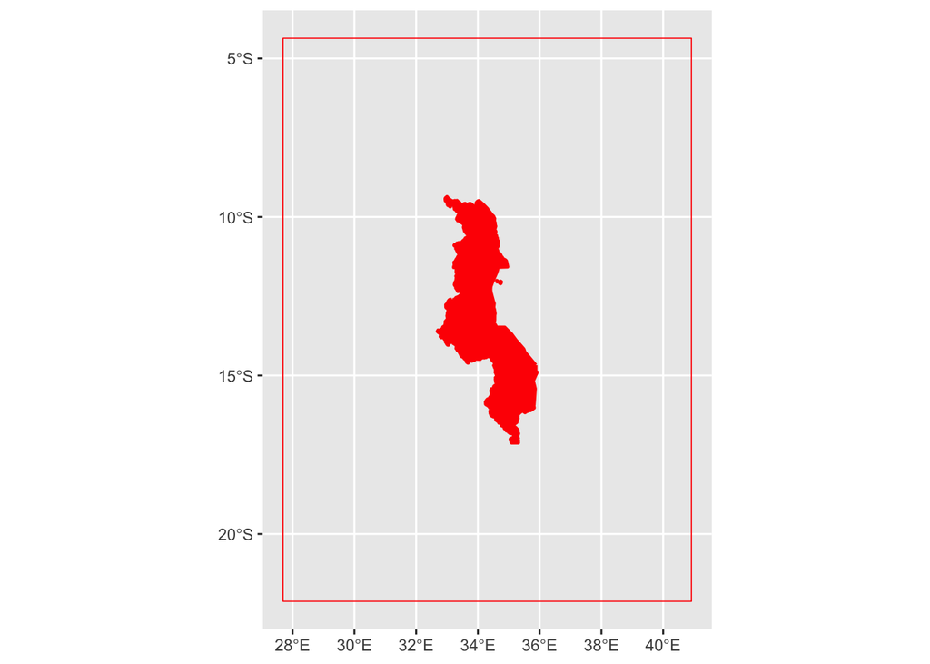

```r
#Creating polygon to indicate zoom
poly <- sp_df %>%
  st_as_sf(coords = c("lon", "lat"),
           crs = st_crs(mwi)) %>%
  st_bbox() %>%
  st_as_sfc()

#Examining what we just created
ggplot() +
  geom_sf(data = mwi, fill="red", color = "red", linewidth = 0.9)+
  geom_sf(data = poly, fill=NA, color = "red", linewidth = 0.3)
```

## 2.4 Cropping the raster

We now crop our raster only to the area of interest. Again, if we have too much, our computer will have a hard time rendering the file.

```r
#Step1: Reducing raster resolution: Higher dx/day values mean lower resolution
elev2<-st_warp(elev, st_as_stars(st_bbox(elev), dx = 0.05, dy = 0.05))
#Step2: Removing really high pixel values for good contrast in MWI
elev2[elev2 > 2000] <- NA
#Step3: Cropping
dem_mwi<-st_crop(elev2, poly)
```

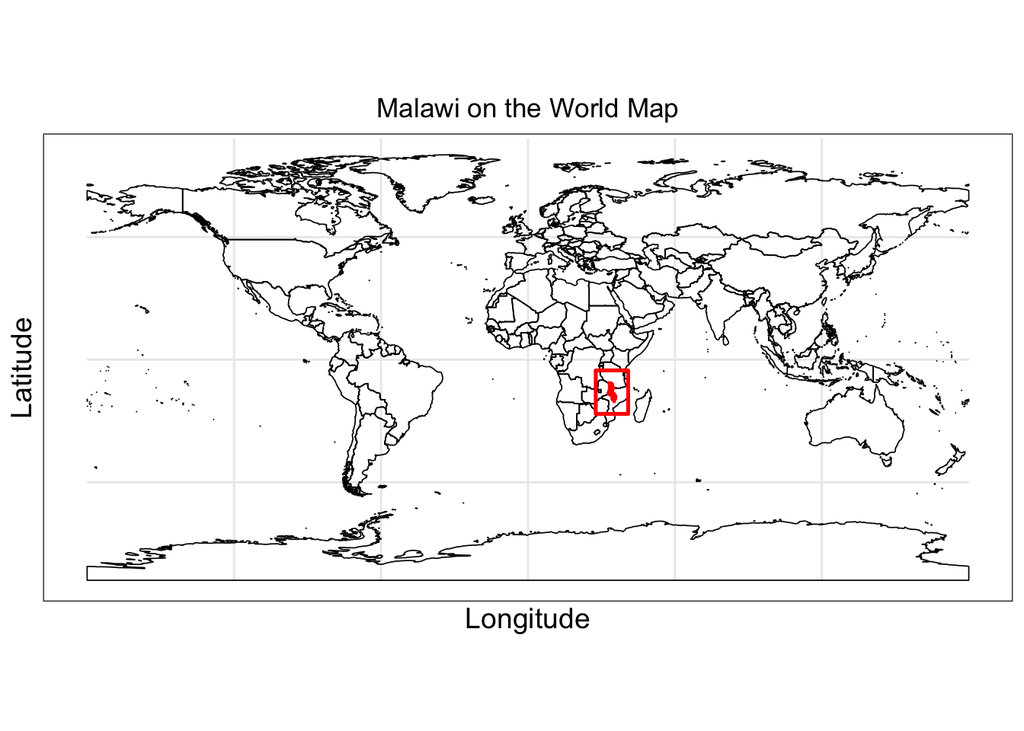

```r
map_word<-ggplot() +
  geom_sf(data = world, fill=NA, color = "black", linewidth = 0.3)+
  geom_sf(data = mwi, fill="red", color = "red", linewidth = 0.7)+
  geom_sf(data = poly, fill=NA, color = "red", linewidth = 0.9)+
  theme_bw()+
  labs(x = "Longitude", y="Latitude")+
  ggtitle("Malawi on the World Map")+
    theme(axis.text.x = element_text(size=14),
        axis.text.y = element_text(size=14),
        axis.title=element_text(size=14),
        plot.title = element_text(hjust = 0.5),
        legend.position = c(1, 0),
        #Legend.position values should be between 0 and 1. c(0,0) corresponds to the "bottom left"
        #and c(1,1) corresponds to the "top right" position.
        legend.box.background = element_rect(fill='white'),
        legend.background = element_blank(),
        legend.text=element_text(size=12))
#ggspatial::annotation_scale(location = 'tr')
map_word
```

```r
ggsave(map_word, file="./graphs/map_world.jpg", height=15, width=30, units = "cm", dpi=300)
```

## 2.5 Mapping the region of interest - Malawi

```r
#Selecting only the region of interest
mwi1_lab<-subset(mwi1, NAME_1=="Nkhata Bay")
#Defining colors for raster
grey_palette <- colorRampPalette(c("grey90", "grey30"))
# Generate a sequence of colors based on the number of breaks desired
num_breaks <- 10  # Adjust this based on your data
grey_colors <- grey_palette(num_breaks)
```

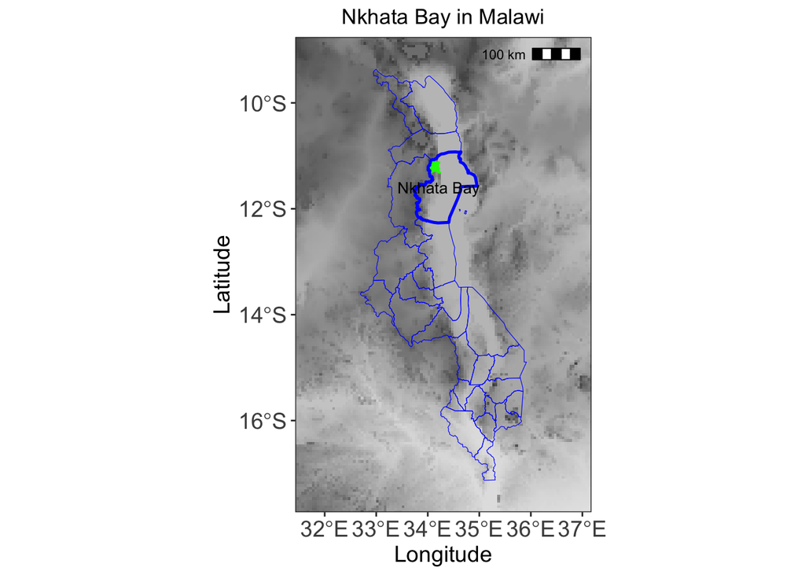

```r
error<-0.2
map_malawi<-ggplot() +
  geom_stars(data=elev2, show.legend=FALSE) +
  scale_fill_gradientn(colours = grey_colors)+
  geom_sf(data = select_comm, fill="green", color = "green", linewidth = 0.4)+
  geom_sf(data = mwi1, fill=NA, color = "blue", linewidth = 0.2)+
  geom_sf(data = mwi1_lab, fill=NA, color = "blue", linewidth = 0.9)+
  geom_sf_text(data=mwi1_lab, aes(label = NAME_1), size=3.5)+
  theme_bw()+
  labs(x = "Longitude", y="Latitude")+
    ggtitle("Nkhata Bay in Malawi")+
    theme(axis.text.x = element_text(size=14),
        axis.text.y = element_text(size=14),
        axis.title=element_text(size=14),
        plot.title = element_text(hjust = 0.5),
        legend.position = c(1, 0),
        #Legend.position values should be between 0 and 1. c(0,0) corresponds to the "bottom left"
        #and c(1,1) corresponds to the "top right" position.
        legend.box.background = element_rect(fill='white'),
        legend.background = element_blank(),
        legend.text=element_text(size=12))+
     coord_sf(xlim = c(min_lon_x-5*error, max_lon_x+5*error), ylim = c(min_lat_y-error, max_lat_y+error))+
      ggspatial::annotation_scale(location = 'tr')
#Saving the map
ggsave(map_malawi, file="./graphs/map_malawi.jpg", height=15, width=15, units = "cm", dpi=300)
map_malawi
```

## 2.6 Calculating the appropriate zoom level for the Selected Communes

We now calculate the zoom level for the region of interest - Nkhata Bay.

```r
#Calculating the appropriate zoom level for the selected commune
mwi_extent <- st_bbox(select_comm)

min_lon_x<-mwi_extent["xmin"]
max_lon_x<-mwi_extent["xmax"]

min_lat_y<-mwi_extent["ymin"]
max_lat_y<-mwi_extent["ymax"]
```

```r
#Re-reading the shapefiles.
#We now want more accurate polygons since we are zooming in.
#This is why we load them again

mwi <- st_read("./data/malawi-latest-free/gadm41_MWI_0.shp")
mwi1 <- st_read("./data/malawi-latest-free/gadm41_MWI_1.shp")
mwi3 <- st_read("./data/malawi-latest-free/gadm41_MWI_3.shp")
select_comm <- st_read("./data/malawi-latest-free/selected_communes3.shp")
dem <- read_stars("./data/elev.tif")

#Step1: Reducing raster resolution: Higher dx/day values mean lower resolution
elev2<-st_warp(dem, st_as_stars(st_bbox(elev), dx = 0.02, dy = 0.02))
#Step2: Removing really high pixel values for good contrast in MWI
elev2[elev2 > 2000] <- NA

#Step3: Creating a dataframe to emphasize Malawi and adding some error
error = 0.5
sp_df = data.frame("lon" = c(min_lon_x - error, max_lon_x + error,
                             min_lon_x - error, max_lon_x + error),
                   "lat" = c(min_lat_y - error, min_lat_y - error,
                             max_lat_y + error, max_lat_y + error))

#Step4: Creating polygon to indicate zoom
poly <- sp_df %>%
  st_as_sf(coords = c("lon", "lat"),
           crs = st_crs(mwi)) %>%
  st_bbox() %>%
  st_as_sfc()

#Step5: Cropping
dem_mwi<-st_crop(elev2, poly)

world <- ne_countries(scale = "medium", returnclass = "sf")
#Turning off spherical geometries
sf::sf_use_s2(FALSE)
```

```r
#We also want to include roads in our map, to provide more context.
#Reading the OSM roads data
roads<-st_read("./data/malawi-latest-free/gis_osm_roads_free_1_crop2.shp")
#Step1: Dissolving polylines
roads2 <- st_combine(roads)
#Step2: Turning roads2 into an sf object
roads3<-st_as_sf(roads2)
#Step3: Only the roads of interest
roads_crop1 <- sf::st_intersection(roads3, select_comm)
```

## 2.7 Mapping the Individuals

Let us first look at our data.

```r
diff_data <- read.csv(file = './data/did_data_geo_malawi.csv')
glimpse(diff_data, n=10)
```

```
Rows: 8,000
Columns: 10
$ year         <int> 2013, 2014, 2015, 2016, 2017, 2018, 2019, 2020, 2013, 201…
$ income       <dbl> 1284.551, 1285.832, 1285.997, 1285.157, 1286.313, 1287.24…
$ age          <int> 33, 34, 35, 36, 37, 38, 39, 40, 51, 52, 53, 54, 55, 56, 5…
$ sex          <chr> "Woman", "Woman", "Woman", "Woman", "Woman", "Woman", "Wo…
$ malaria_risk <dbl> 36.26529, 35.10382, 73.17664, 28.98390, 51.18721, 51.9071…
$ id           <int> 1, 1, 1, 1, 1, 1, 1, 1, 2, 2, 2, 2, 2, 2, 2, 2, 3, 3, 3, …
$ lat          <dbl> -11.27476, -11.27476, -11.27476, -11.27476, -11.27476, -1…
$ lon          <dbl> 34.03006, 34.03006, 34.03006, 34.03006, 34.03006, 34.0300…
$ after        <int> 0, 0, 0, 0, 0, 1, 1, 1, 0, 0, 0, 0, 0, 1, 1, 1, 0, 0, 0, …
$ city         <chr> "City A", "City A", "City A", "City A", "City A", "City A…
```

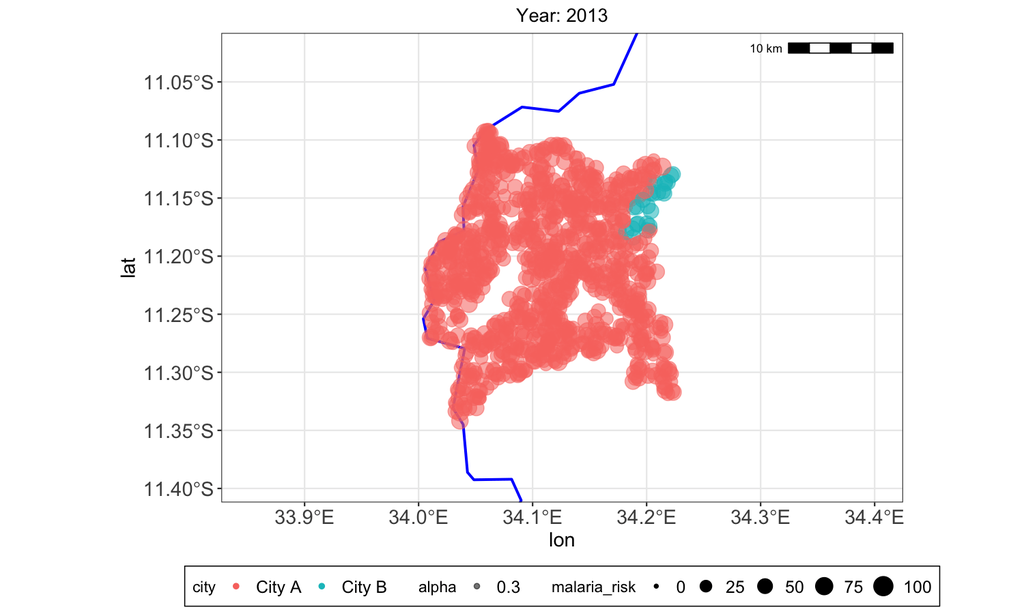

```r
error<-0.05
figure_animated<-ggplot() +
  geom_sf(data = mwi1_lab, fill=NA, color = "blue", linewidth = 0.9)+
  geom_point(data = diff_data, aes(x=lon, y=lat, color = city, size = malaria_risk, alpha=0.3))+
  theme_bw()+
  labs(x = "Longitude", y="Latitude")+
  ggtitle("The Three Districts Selected in Nkhata Bay, Malawi\n Location of 1000 Individuals\n For the Experiment")+
    theme(axis.text.x = element_text(size=14),
        axis.text.y = element_text(size=14),
        axis.title=element_text(size=14),
        plot.title = element_text(hjust = 0.5),
        #Legend.position values should be between 0 and 1. c(0,0) corresponds to the "bottom left"
        #and c(1,1) corresponds to the "top right" position.
        legend.box.background = element_rect(fill='white'),
        legend.background = element_blank(),
        legend.text=element_text(size=12),
        legend.position="bottom")+
  coord_sf(xlim = c(min_lon_x-3*error, max_lon_x+3*error), ylim = c(min_lat_y-error, max_lat_y+error))+
  ggspatial::annotation_scale(location = 'tr')+
  labs(title = 'Year: {frame_time}', x = 'lon', y = 'lat')+
  transition_states(year)+
  transition_time(as.integer(year))


suppressWarnings(animate(figure_animated, height = 900, width =1500, fps = 4,
                         res = 150,
                         nframes=max(diff_data$year, na.rm=T)-min(diff_data$year, na.rm=T)))
```

# 3 Data Analysis

We will now do the data analysis. Until now, we looked at various ways of mapping our data.

## 3.1 Summary statisics

Before we conduct any analysis, it is important to get a sense of our data, the minimum and maximum, the mean, and whether our variables are normally distributed or not. Let us now create a summary statistics table:

```r
datasummary_skim(diff_data)
```

|  | Unique (#) | Missing (%) | Mean | SD | Min | Median | Max |  |
| --- | --- | --- | --- | --- | --- | --- | --- | --- |
| year | 8 | 0 | 2016.5 | 2.3 | 2013.0 | 2016.5 | 2020.0 |  |
| income | 8000 | 0 | 1249.9 | 160.6 | 836.3 | 1246.8 | 1710.7 |  |
| age | 87 | 0 | 32.3 | 16.0 | 1.0 | 31.0 | 87.0 |  |
| malaria_risk | 8000 | 0 | 48.9 | 12.7 | 0.0 | 49.0 | 100.0 |  |
| id | 1000 | 0 | 500.5 | 288.7 | 1.0 | 500.5 | 1000.0 |  |
| lat | 1000 | 0 | −11.2 | 0.1 | −11.3 | −11.2 | −11.1 |  |
| lon | 1000 | 0 | 34.1 | 0.1 | 34.0 | 34.1 | 34.2 |  |
| after | 2 | 0 | 0.4 | 0.5 | 0.0 | 0.0 | 1.0 |  |

## 3.2 Estimating the Difference

So, we are interested in the causal effect of the program - $\beta_3 (\text{Group}_i \times \text{Time}_t)$. We can find this causal effect by calculating:

$$Y_{it} = \beta_0 + \beta_1 \text{Group}_i + \beta_2 \text{Time}_t + \beta_3 (\text{Group}_i \times \text{Time}_t) + \epsilon_{it}$$

We can calculate $\beta_3 (\text{Group}_i \times \text{Time}_t)$ by running:

```r
model_did <- lm(malaria_risk ~ city + after + city * after, data = diff_data)
options(modelsummary_format_numeric_latex = "plain")
modelsummary(model_did, stars = TRUE,  gof_map = c("nobs", "r.squared"))
```

|  | (1) |
| --- | --- |
| (Intercept) | 50.629*** |
|  | (0.179) |
| cityCity B | 3.071** |
|  | (1.155) |
| after | −4.532*** |
|  | (0.292) |
| cityCity B × after | −7.623*** |
|  | (1.886) |
| Num.Obs. | 8000 |
| R2 | 0.034 |

+ p < 0.1, * p < 0.05, ** p < 0.01, *** p < 0.001

Let us now also plot this difference. This is also called an “event-study” plot.

```r
plot_data <- diff_data %>%
  group_by(year, city) %>%
  summarize(mean_risk = mean(malaria_risk),
            se_risk = sd(malaria_risk) / sqrt(n()),
            upper = mean_risk + (1.96 * se_risk),
            lower = mean_risk + (-1.96 * se_risk))
```

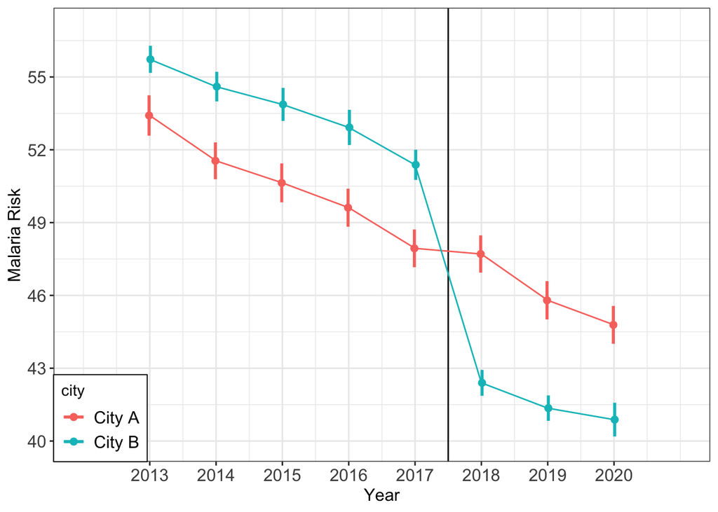

```r
mean_risk<-ggplot(plot_data, aes(x = year, y = mean_risk, color = city)) +
  geom_vline(xintercept = 2017.5) +
    geom_errorbar(aes(ymin = lower, ymax = upper),
                size = 1, width = 0,
                position=position_dodge(width=0.04))+
  geom_line() +
    geom_point(size = 2,
             position=position_dodge(width=0.04))+
  theme(legend.position = "bottom")+
    labs(x = "Year", y = "Malaria Risk")+
   scale_y_continuous(breaks = (seq(40, 57, by = 3)),
                      limits = c(40, 57))+
  scale_x_continuous(breaks = (seq(2013, 2020, by = 1)),
                     limits = c(2012, 2021))+
  theme_bw() +
  theme(axis.text.x = element_text(size=12),
        axis.text.x.top  = element_text(size=10, angle = 45, margin=margin(5,5,10,5,"pt")),
        axis.text.y = element_text(size=12),
        axis.title=element_text(size=12),
        plot.title = element_text(hjust = 0.5),
        legend.position = c(1, 0),
        #Legend.position values should be between 0 and 1. c(0,0) corresponds to the "bottom left"
        #and c(1,1) corresponds to the "top right" position.
        legend.box.background = element_rect(fill='white'),
        legend.background = element_blank(),
        legend.text=element_text(size=12))
  mean_risk<-reposition_legend(mean_risk, 'bottom left')
```

```r
ggsave(mean_risk, file = "./graphs/fig_dif_dif.jpg",
       height = 12, width = 20,
       units = "cm", dpi = 200)
```

We can see that parallel trends hold prior to the intervention. Regions in both cities A and B have a decreasing trend in the risk of malaria. After the intervention, it seems that people from city B have an even lower risk of malaria.

# 4 Conclusion

We can now conclude that indeed the provision of insecticide-treated nets reduces the risk of malaria by 7.623 units. Thus, if the we want to reduce such a health risk to the wider region, it might be effective to provide such nets to all vulnerable populations.